# Analiza Rynku Mieszkaniowego

Raport analityczny

Kacper Ciszewski, Michał Dalach, Wiktor Drozdowski

2026-02-15

# 1. Wstęp i Cel Projektu

**Cel Analizy**: Celem niniejszego badania jest zidentyfikowanie oraz ocena siły oddziaływania kluczowych determinant cenowych na rynku nieruchomości mieszkalnych w Polsce. Analiza koncentruje się na wielowymiarowym badaniu zależności między cechami fizycznymi lokalu, infrastrukturą otoczenia a ceną transakcyjną. Projekt zakłada dwuetapową weryfikację hipotez: w ujęciu globalnym (dla całego zbioru danych) oraz w ujęciu lokalnym, poprzez szczegółową analizę specyfiki wybranych rynków miejskich (np. Warszawy,Gdańska), co pozwoli na uchwycenie niuansów lokalizacyjnych wpływających na wycenę.

## 1.1 O Danych

**Źródło danych:** [https://www.kaggle.com/datasets/krzysztofjamroz/apartment-prices-in-poland/?select=apartments_pl_2023_08.csv]

## 1.2. Słownik Zmiennych (Data Dictionary)

Poniższa tabela przedstawia opis zmiennych dostępnych w analizowanym zbiorze danych:

Słownik Zmiennych (Data Dictionary)

| Nazwa Zmiennej | Opis |
| --- | --- |
| id | Unikalny identyfikator ogłoszenia |
| city | Miasto, w którym znajduje się nieruchomość |
| price | Cena ofertowa (PLN) |
| squareMeters | Powierzchnia mieszkania w m² |
| rooms | Liczba pokoi |
| floor / floorCount | Piętro mieszkania / Liczba pięter |
| buildYear | Rok budowy budynku |
| type | Rodzaj zabudowy |
| ownership | Forma własności |
| lat / lon | Współrzędne geograficzne |
| centreDistance | Odległość od centrum (km) |
| poiCount | Liczba punktów POI (500m) |
| *Distance | Odległości do: szkół, przychodni itp. |
| has*Parking, Balkon, Winda, Ochrona… | Czy ma dane udogodnienie (TAK/NIE) |

# 2. Porządkowanie i czyszczenie danych

Proces przygotowania danych do analizy został podzielony na kilka kluczowych etapów: definicję reguł poprawności, wstępną walidację, imputację braków danych (metodami statystycznymi i uczenia maszynowego) oraz weryfikację końcową.

## 2.1. Definicja Reguł Walidacyjnych

Przed przystąpieniem do czyszczenia zdefiniowano zestaw reguł logicznych przy użyciu pakietu validate. Pozwoliło to na identyfikację błędów w surowym zbiorze danych.

Sprawdzono m.in.:

Spójność logiczną: Czy piętro mieszkania nie jest wyższe niż liczba pięter w budynku (Logic_Floor).

Zasady budowlane: Czy w budynkach jednopiętrowych nie zadeklarowano windy (Logic_Elevator).

Wiarygodność cen: Czy cena mieści się w przedziale 100 tys. – 10 mln PLN.

Geolokalizację: Czy współrzędne geograficzne znajdują się w granicach Polski (Bounding Box).

Kompletność dystansów: Czy odległości do punktów POI są wartościami dodatnimi.

Wstępna walidacja wykazała naruszenia, które zostały skorygowane w kolejnych krokach.

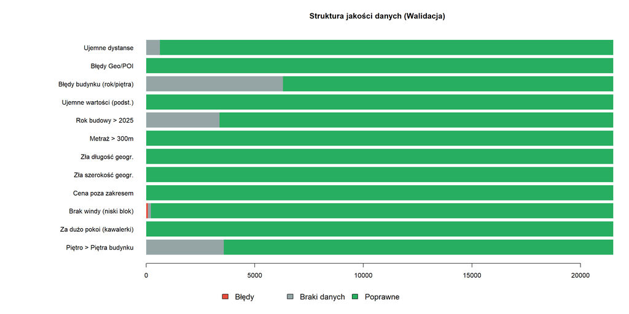

## 2.2. Strategia Czyszczenia i Imputacji

Wdrożono wieloetapowy potok przetwarzania danych (pipeline), obejmujący:

Wykluczenie zmiennych buildingMaterial oraz condition. Decyzja ta została podyktowana znacznym stopniem niekompletności danych (brakujące wartości) oraz niską jakością informacji źródłowych, co uniemożliwiało przeprowadzenie rzetelnej analizy statystycznej w tym zakresie.

Imputacja logiczna:

Braki w liczbie pięter (floor) uzupełniono wartością mediany (3) lub wartością floorCount, jeśli była mniejsza niż 3.

Informację o windzie (hasElevator) wywnioskowano na podstawie wysokości budynku (przyjęto, że budynki powyżej 4 pięter posiadają windę).

Imputacja statystyczna (Dystanse): Brakujące odległości do punktów usługowych (*Distance) uzupełniono średnią arytmetyczną obliczoną lokalnie dla każdego miasta.

Imputacja algorytmiczna (kNN): Brakujący rok budowy (buildYear) uzupełniono metodą k-Najbliższych Sąsiadów (kNN), bazując na podobieństwie pod względem liczby punktów POI oraz odległości od centrum.

## 2.3. Zaawansowana Imputacja (Random Forest)

Do uzupełnienia braków w kluczowej zmiennej kategorycznej type (rodzaj zabudowy) zastosowano model uczenia maszynowego Random Forest (las losowy). Model został wytrenowany na kompletnych obserwacjach (500 drzew decyzyjnych), a następnie wykorzystany do predykcji typu budynku dla brakujących rekordów, co pozwoliło na zachowanie struktury danych lepiej niż proste uzupełnienie dominantą.

## 2.4. Wyniki i Weryfikacja Końcowa

Po zakończeniu procesu czyszczenia przeprowadzono:

Ponowną walidację: Sprawdzono zgodność danych z regułami validate.

Analizę braków (naniar): Potwierdzono wyeliminowanie kluczowych braków danych.

Zapis: Przetworzony zbiór danych został zapisany do pliku .RData w celu optymalizacji wydajności raportu.

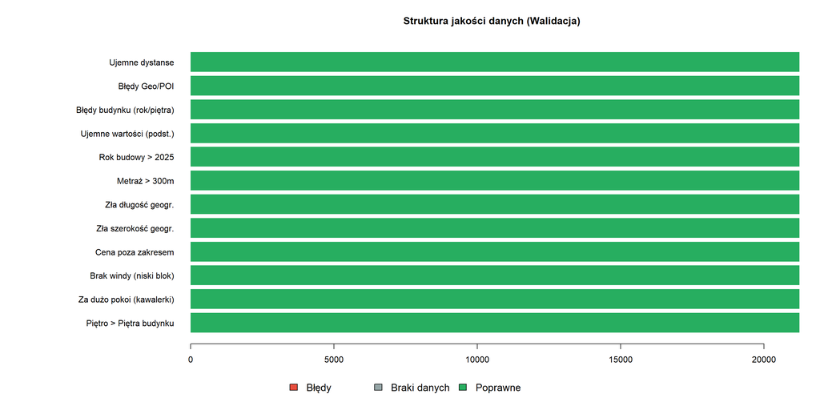

# 3. Analiza opisowa rynku nieruchomości

## 3.1 Ogólna charakterystyka cen mieszkań w Polsce

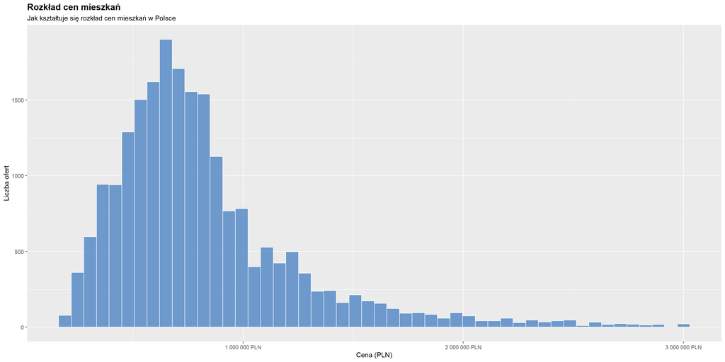

Rozkład cen cechuje się silną asymetrią prawostronną, z największą koncentracją ofert w przedziale od 500 000 do 850 000 PLN. Dominacja tego segmentu wyznacza rynkowy standard cenowy, podczas gdy oferty powyżej 1,5 mln PLN stanowią nieliczną grupę nieruchomości luksusowych. Wyraźny brak ogłoszeń poniżej 250 000 PLN definiuje wysoki próg wejścia na badany rynek. Obecność wartości odstających, sięgających nawet 3 mln PLN, powoduje, że średnia arytmetyczna jest zawyżona. W konsekwencji to mediana, a nie średnia, najlepiej oddaje realny koszt zakupu typowego mieszkania.

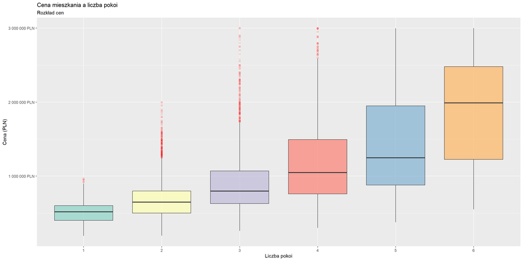

Wykres prezentuje wyraźną korelację dodatnią między liczbą pokoi a ceną nieruchomości, przy czym wraz ze wzrostem metrażu obserwuje się nie tylko wzrost mediany, ale także znaczące rozszerzenie rozstępu międzykwartylowego. Rynek mieszkań 1- i 2-pokojowych charakteryzuje się największą stabilnością i koncentracją cenową, gdzie niski próg wejścia oscyluje wokół 400 000 PLN, natomiast segmenty 3- i 4-pokojowe wykazują silną asymetrię prawostronną z licznymi wartościami odstającymi sięgającymi nawet 3 mln PLN. Obecność tak wysokich wartości ekstremalnych w segmencie średniej wielkości mieszkań świadczy o silnie rozwiniętym rynku premium, który istotnie zawyża średnią arytmetyczną, czyniąc medianę najbezpieczniejszym wskaźnikiem typowej ceny transakcyjnej. W przypadku największych lokali, mających 5 i 6 pokoi, korpusy wykresów stają się znacznie wyższe, co sugeruje, że w tej kategorii liczba pokoi przestaje być dominującym czynnikiem cenotwórczym na rzecz standardu wykończenia i prestiżowej lokalizacji. Całość obrazuje strukturę rynkową, w której ryzyko cenowe i dyspersja ofert rosną progresywnie wraz z wielkością nieruchomości, definiując rynek o wysokim stopniu zróżnicowania jakościowego.

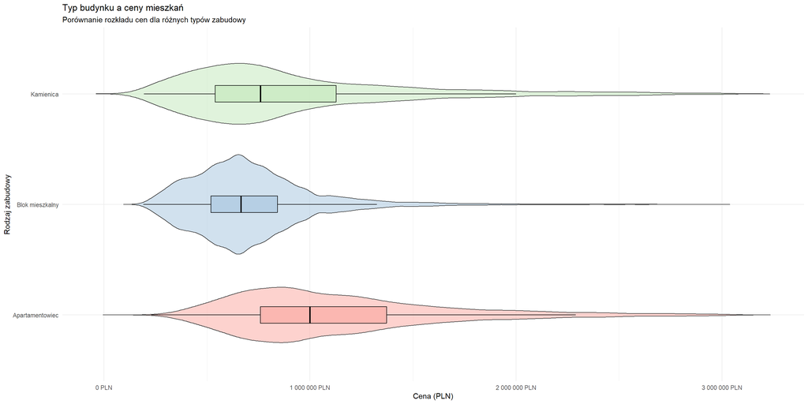

[interactive chart not shown]

Mapa punktowa ofert prezentuje możliwość oceny koncentracji ofert w miastach wraz z rozkładem cen w odróżnienu od innych miast, ale również dzielnic. Mapa ukazuje różnice cenowe między dzielnicami centralnymi, a obrzeżami zwanymi dzielnicami mieszkalnymi.

[interactive chart not shown]

Mapa bąbelkowa uwidacznia drastyczne dysproporcje w średnich cenach mieszkań, gdzie dominująca wielkość i ciemny kolor bąbla nad Warszawą wyznacza ogólnokrajowy szczyt cenowy przekraczający 1 000 000 PLN. Wysoki poziom cenowy utrzymuje się również w aglomeracji krakowskiej i trójmiejskiej, podczas gdy mniejsze ośrodki, takie jak Radom czy Częstochowa, reprezentowane są przez jasne punkty sygnalizujące znacznie niższy koszt zakupu nieruchomości. Rozkład ten potwierdza, że kapitał jest silnie skoncentrowany w kilku kluczowych metropoliach, co tworzy wyraźny podział na drogie rynki regionalne i bardziej przystępne cenowo obszary reszty kraju.

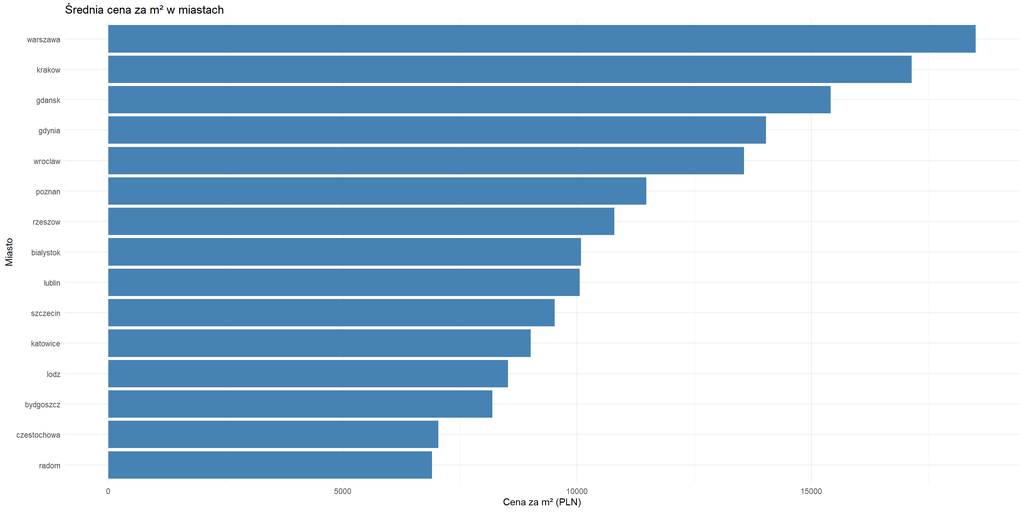

Wykres słupkowy prezentuje wyraźną hierarchię cenową polskich miast, w której Warszawa deklasuje pozostałe ośrodki z rekordową średnią stawką przekraczającą 18 000 PLN za m². Drugi segment rynku tworzą Kraków oraz Gdańsk, gdzie ceny oscylują w granicach 15 000 – 17 000 PLN, podczas gdy na przeciwległym biegunie znajdują się Radom i Częstochowa z ofertami poniżej 7 500 PLN za m². Tak duża rozpiętość — sięgająca ponad 150% między stolicą a miastami o najniższych stawkach — obrazuje głębokie rozwarstwienie ekonomiczne kraju i koncentrację popytu inwestycyjnego w kilku kluczowych metropoliach.

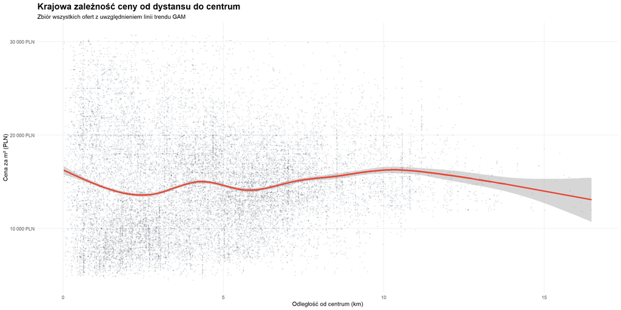

Wykres rozrzutu z linią trendu GAM obrazuje złożoną zależność ceny za m² od odległości lokalu od centrum, podważając prosty schemat liniowego spadku wartości wraz z oddalaniem się od rdzenia miasta. Choć najwyższe stawki jednostkowe, przekraczające 25 000 PLN, koncentrują się w bezpośrednim sąsiedztwie centrum (0–2 km), linia trendu wykazuje charakterystyczne falowanie, z lokalnym wzrostem cen w okolicach 10. kilometra, co sugeruje wysoką wycenę prestiżowych dzielnic sypialnianych oraz nowoczesnych osiedli apartamentowych na obrzeżach metropolii. Ogromna chmura punktów poniżej 15 000 PLN, rozciągająca się jednostajnie wzdłuż całej osi odległości, świadczy o szerokiej dostępności lokali o niższym standardzie niezależnie od lokalizacji, podczas gdy wyraźne zwężenie rozkładu powyżej 15 km sygnalizuje ostateczny spadek stawek na terenach podmiejskich. W efekcie wykres dowodzi, że o ile ścisłe centrum generuje rekordowe ceny ofertowe, o tyle wtórne rynki lokalne i segmenty premium poza centrum skutecznie stabilizują średnią cenę za metr kwadratowy na poziomie około 15 000 PLN dla większości badanego obszaru.

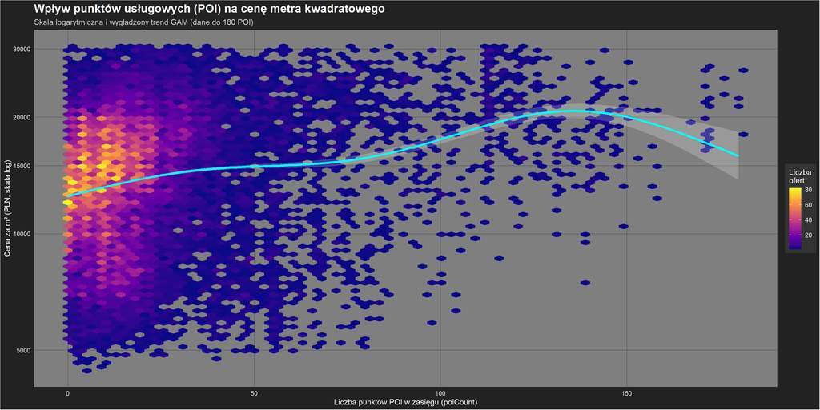

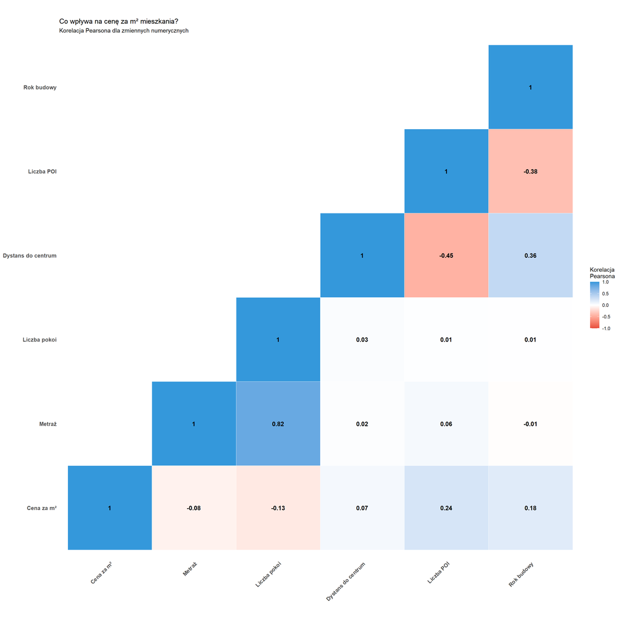

Macierz korelacji Pearsona wskazuje na zróżnicowany wpływ poszczególnych zmiennych na cenę za m², przy czym najsilniejszym dodatnim czynnikiem powiązanym z wartością jednostkową nieruchomości jest liczba punktów usługowych (POI) w zasięgu, co potwierdza wysoką rynkową wycenę infrastruktury miejskiej. Co ciekawe, metraż oraz liczba pokoi wykazują słabą korelację ujemną z ceną za m², co sugeruje, że wraz ze wzrostem całkowitej powierzchni mieszkania, stawka za pojedynczy metr kwadratowy ma tendencję do lekkiego spadku. Jednocześnie obserwujemy silne, naturalne współzależności między metrażem a liczbą pokoi (0.82) oraz istotną korelację ujemną między dystansem do centrum a liczbą punktów POI (-0.45), co dowodzi, że im dalej od serca miasta, tym uboższa staje się oferta usługowa, co pośrednio rzutuje na finalną wycenę lokalu.

#### Filtry

Odległość od centrum (km)

Metraż (m²)

Winda

Nie

Tak

[interactive chart not shown]

Powyższy moduł umożliwia dynamiczną segmentację rynku. Manipulując suwakami, można zaobserwować zjawisko elastyczności cenowej: przy zmniejszaniu odległości od centrum (< 3 km), histogram wyraźnie przesuwa się w prawo i spłaszcza, co potwierdza występowanie znacznej premii lokalizacyjnej oraz większe rozwarstwienie cen w prestiżowych dzielnicach.

| Statystyka | bialystok | bydgoszcz | czestochowa | gdansk | gdynia | katowice | krakow | lodz | lublin | poznan | radom | rzeszow | szczecin | warszawa | wroclaw |
| --- | --- | --- | --- | --- | --- | --- | --- | --- | --- | --- | --- | --- | --- | --- | --- |
| Min | 299000 | 199999 | 195000 | 415000 | 409000 | 195000 | 399000 | 191000 | 335000 | 330000 | 198000 | 330000 | 309000 | 499000 | 399000 |
| Max | 850000 | 949000 | 780000 | 2499000 | 2800000 | 1315000 | 2790000 | 986000 | 1149990 | 1395000 | 810000 | 1250000 | 1200000 | 3000000 | 1600000 |
| Kwartyl dolny | 409475 | 330000 | 280000 | 629000 | 589925 | 375000 | 660000 | 330000 | 475000 | 511335 | 298750 | 498500 | 449000 | 735937.5 | 589249.75 |
| Mediana | 496950 | 395000 | 355000 | 765000 | 720000 | 470000 | 800000 | 399990 | 555000 | 599000 | 349500 | 596500 | 540000 | 899000 | 695000 |
| Kwartyl górny | 595000 | 529000 | 451800 | 1024798.25 | 1045000 | 649364 | 1074000 | 515000 | 660000 | 746000 | 430000 | 699000 | 660000 | 1220500 | 849000 |
| Średnia | 510072.46 | 435235.03 | 381323.63 | 891727.6 | 885497.41 | 526931.13 | 940685.05 | 441169.44 | 581884.98 | 646852.72 | 378414 | 638886.41 | 573058.48 | 1052473.32 | 745812.93 |
| Odch. std. | 128115.65 | 148183.54 | 129771.28 | 391120.03 | 449581.33 | 215390.8 | 424074.03 | 155554.52 | 151621.5 | 197934.85 | 120558.75 | 201230.33 | 174120.11 | 467031.82 | 231955.14 |
| IQR | 185525 | 199000 | 171800 | 395798.25 | 455075 | 274364 | 414000 | 185000 | 185000 | 234665 | 131250 | 200500 | 211000 | 484562.5 | 259750.25 |
| Odchylenie ćwiartkowe | 92762.5 | 99500 | 85900 | 197899.12 | 227537.5 | 137182 | 207000 | 92500 | 92500 | 117332.5 | 65625 | 100250 | 105500 | 242281.25 | 129875.12 |
| Odch. std. w % | 0.25 | 0.34 | 0.34 | 0.44 | 0.51 | 0.41 | 0.45 | 0.35 | 0.26 | 0.31 | 0.32 | 0.31 | 0.3 | 0.44 | 0.31 |

[output cut: 3 more lines]

| Statystyka | Apartamentowiec | Blok | Kamienica |
| --- | --- | --- | --- |
| Min | 5588.67 | 4471.91 | 4883.01 |
| Max | 30571.29 | 30651.94 | 30702.75 |
| Kwartyl dolny | 14628.25 | 10135.14 | 9281.77 |
| Mediana | 18188.43 | 13464.15 | 13801.99 |
| Kwartyl górny | 21500 | 16398.39 | 19101.09 |
| Średnia | 18261.18 | 13571.59 | 14533.8 |
| Odch. std. | 4953.77 | 4422.05 | 6252.42 |
| IQR | 6871.75 | 6263.26 | 9819.32 |
| Odchylenie ćwiartkowe | 3435.87 | 3131.63 | 4909.66 |
| Odch. std. w % | 0.27 | 0.33 | 0.43 |

[output cut: 3 more lines]

Analiza danych wykazuje, że segment apartamentowców charakteryzuje się najwyższym prestiżem cenowym, osiągając średnią na poziomie 18 261,18 zł za metr kwadratowy oraz medianę wynoszącą 18 188,43. W porównaniu do bloków i kamienic, apartamentowce cechują się największą stabilnością cenową, co potwierdza najniższy współczynnik zmienności (odchylenie standardowe w % wynosi 0,27) oraz niemal symetryczny rozkład wartości. Z kolei kamienice, mimo niższej średniej ceny (14 533,8), wykazują największe zróżnicowanie wewnętrzne, o czym świadczy najwyższe odchylenie standardowe oraz najwyższy rozstęp międzykwartylowy (IQR) wynoszący 9819,32. Wszystkie badane kategorie posiadają dodatnią skośność, co wskazuje na przewagę ofert o cenach niższych niż średnia, przy czym najsilniejszą tendencję w tym kierunku obserwujemy w przypadku tradycyjnych bloków.

## 3.2 Analiza różnic cenowych między Warszawą a Gdańskiem

W niniejszym podrozdziale zestawiono dwa duże rynki w Polsce: **stołeczną Warszawę**, będącą centrum biznesowym, oraz **Gdańsk**, pełniący rolę kluczowego ośrodka turystycznego i portowego. Bezpośrednia analiza porównawcza pozwala oszacować “premię stołeczną” oraz zweryfikować, w jakim stopniu segmenty cenowe obu aglomeracji się pokrywają. Zbadanie różnic w rozkładach cen jest kluczowe dla oceny, czy gdański rynek premium stanowi cenową alternatywę dla standardowych inwestycji w stolicy.

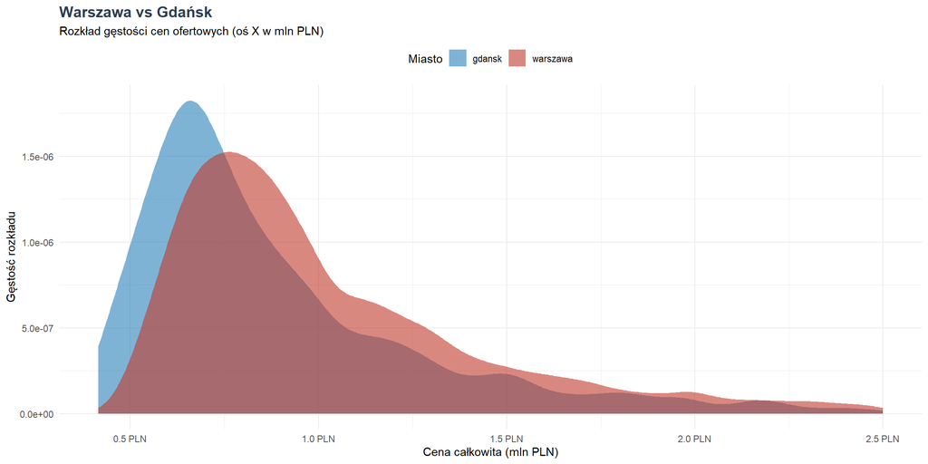

Analiza wizualna ujawnia zasadnicze różnice w strukturze obu rynków. Gdańsk charakteryzuje się rozkładem o wysokiej smukłości, co oznacza dużą koncentrację ofert w wąskim przedziale cenowym między sześćset a siedemset tysięcy złotych. Rynek ten jest przez to bardziej jednorodny i przewidywalny z punktu widzenia inwestora.

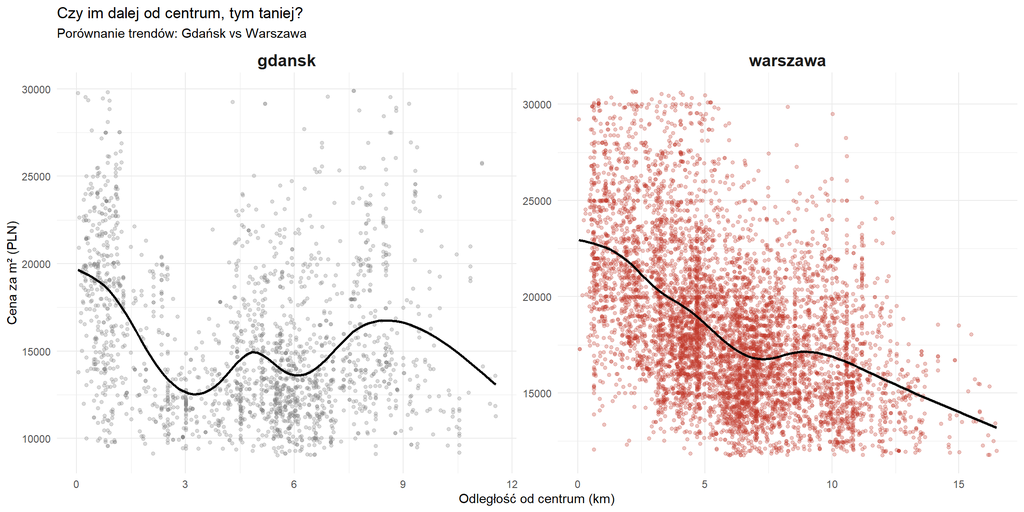

Interpretacja trendów lokalizacyjnych ukazuje zasadnicze różnice w strukturze przestrzennej obu aglomeracji:

Warszawa reprezentuje model monocentryczny, w którym zależność cen od lokalizacji przybiera postać wyraźnej ujemnej korelacji liniowej. Najwyższe stawki, przekraczające dwadzieścia pięć tysięcy złotych za metr kwadratowy, skupiają się w ścisłym centrum miasta. Wraz z oddalaniem się od serca stolicy wartość nieruchomości spada w sposób niemal jednostajny, co stanowi klasyczny przykład renty lokalizacyjnej, gdzie odległość od centralnego punktu orientacyjnego jest głównym czynnikiem determinującym cenę.

Gdańsk natomiast wpisuje się w model pasmowy i policentryczny, co sprawia, że wykres cen jest znacznie bardziej złożony. W promieniu dwóch kilometrów od historycznego Śródmieścia wysokie ceny są podyktowane walorami turystycznymi oraz rynkiem najmu krótkoterminowego. Następnie, w odległości trzech do czterech kilometrów, następuje lokalny spadek cen w dzielnicach o charakterze sypialnianym, które mimo bliskości starówki nie posiadają jej prestiżu. Kolejny wzrost stawek obserwuje się w przedziale od pięciu do dziewięciu kilometrów. Wynika to ze specyfiki Centralnego Pasma Usługowego, obejmującego biznesowe ośrodki w Oliwie i Wrzeszczu, oraz atrakcyjności pasa nadmorskiego. W rezultacie w Gdańsku centrum nie stanowi pojedynczego punktu, lecz oś komunikacyjną, co powoduje, że nieruchomości położone daleko od zabytkowego rdzenia miasta mogą osiągać wyceny porównywalne z ofertami w samym Śródmieściu.

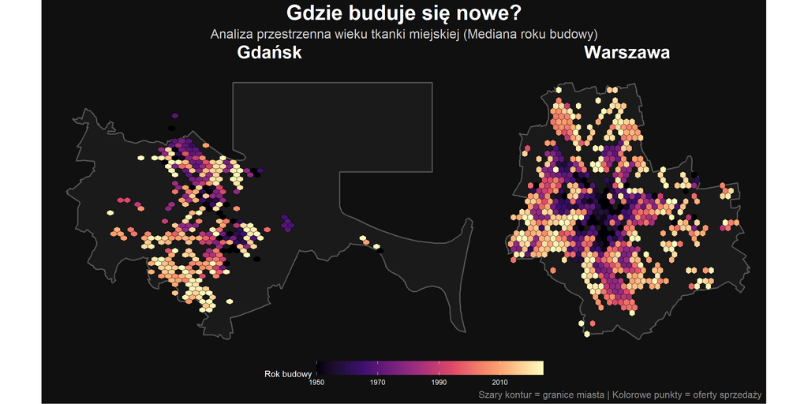

Analiza przestrzenna struktury wieku zabudowy wykorzystuje agregację heksagonalną, co pozwala na precyzyjne zbadanie rozkładu inwestycji mieszkaniowych. Przyjęcie mediany roku budowy jako głównego wskaźnika umożliwia pominięcie wpływu pojedynczych, współczesnych obiektów w starszych dzielnicach i skupienie się na dominującym charakterze architektonicznym danego rejonu.

Zestawienie to ukazuje dwa odmienne modele rozwoju aglomeracji. W Warszawie obserwujemy model monocentryczny, potocznie określany mianem efektu obwarzanka. Śródmieście oraz przyległe do niego dzielnice, takie jak Mokotów, Ochota czy Żoliborz, tworzą ciemniejszy rdzeń zdominowany przez tkankę historyczną oraz budownictwo z okresu PRL. Z kolei na obrzeżach miasta, w dzielnicach takich jak Białołęka, Ursus czy Wilanów, wyraźnie zarysowuje się jasny pierścień nowej zabudowy. Świadczy to o intensywnym procesie rozlewania się miasta i wypychaniu najnowszych inwestycji na peryferia, gdzie większa dostępność gruntów pozwala na zachowanie niższych cen.

Gdańsk prezentuje odmienny, pasmowy model rozwoju, silnie skorelowany z główną osią komunikacyjną oraz linią kolejową. Starsza zabudowa koncentruje się wzdłuż tego ciągu oraz w historycznym Śródmieściu. Ekspansja nowych inwestycji nie ma tu charakteru pierścieniowego, lecz kieruje się przede wszystkim na południe, poza linię obwodnicy, tworząc nowoczesne dzielnice sypialniane w rejonie Jasienia i Gdańska Południe. Porównanie obu miast prowadzi do wniosku, że o ile w stolicy nowe budownictwo jest tożsame z dużą odległością od centrum, o tyle w Gdańsku inwestycje te albo intensywnie uzupełniają luki w pasie nadmorskim, albo tworzą skondensowany ośrodek mieszkaniowy na południowych krańcach aglomeracji.

| Statystyka | gdansk (1 p.) | gdansk (2 p.) | gdansk (3 p.) | gdansk (4 p.) | warszawa (1 p.) | warszawa (2 p.) | warszawa (3 p.) | warszawa (4 p.) |
| --- | --- | --- | --- | --- | --- | --- | --- | --- |
| Min | 415000 | 415000 | 450000 | 567000 | 499000 | 499000 | 550000 | 685000 |
| Kwartyl dolny | 450000 | 569500 | 694841 | 839450 | 550000 | 680000 | 858250 | 1099000 |
| Mediana | 500000 | 659000 | 809500 | 1050000 | 599000 | 790000 | 1050000 | 1448000 |
| Kwartyl górny | 584999 | 847000 | 1130000 | 1499000 | 675000 | 949000 | 1335750 | 1900000 |
| Max | 799000 | 1880000 | 2399000 | 2499000 | 955000 | 2000000 | 3000000 | 3000000 |
| Średnia | 526585.9 | 721851.71 | 946361.98 | 1203469.34 | 626137.92 | 844199 | 1155834.3 | 1562084.72 |
| Odch. std. | 93033.46 | 219634.36 | 353166.67 | 463297.19 | 100110.96 | 228155.86 | 409147.76 | 562169.48 |
| IQR | 134999 | 277500 | 435159 | 659550 | 125000 | 269000 | 477500 | 801000 |
| Skośność | 0.93 | 1.48 | 1.4 | 0.86 | 1.02 | 1.4 | 1.42 | 0.76 |

Przedstawione dane wskazują na systematyczny wzrost cen nieruchomości wraz z liczbą pokoi, przy czym Warszawa konsekwentnie pozostaje rynkiem droższym od Gdańska we wszystkich kategoriach. Różnice te pogłębiają się wraz z metrażem, co widać szczególnie w segmencie lokali czteropokojowych, gdzie mediana w stolicy jest o blisko 400 tys. zł wyższa niż w Gdańsku. W obu miastach występuje prawostronna asymetria rozkładu oraz rosnące rozproszenie cen w większych mieszkaniach, co sugeruje duży wpływ ofert luksusowych na średnie rynkowe, zwłaszcza w Warszawie, gdzie ceny maksymalne osiągają poziom 3 mln zł.

## 3.3 Testy statystyczne

```
## Levene's Test for Homogeneity of Variance (center = median)
##          Df F value    Pr(>F)
## group     2  820.33 < 2.2e-16 ***
##       21237
## ---
## Signif. codes:  0 '***' 0.001 '**' 0.01 '*' 0.05 '.' 0.1 ' ' 1
```

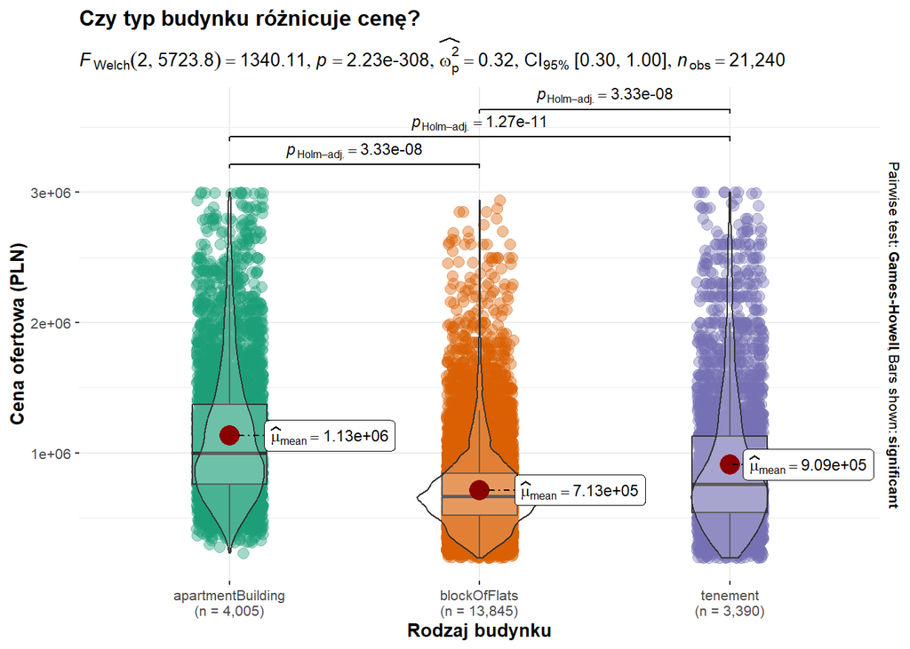

**Do sekcji 1 Typ budynku:** Przeprowadzony test ANOVA (Welcha) wykazał bardzo silną istotność statystyczną ($p < 0.001$). Odrzucamy hipotezę zerową – rodzaj budynku jest kluczowym czynnikiem różnicującym cenę.

Ranking cenowy: Najwyższe średnie ceny osiągają apartamentowce (apartmentBuilding) (śr. ~1.13 mln PLN). Są one zdecydowanie droższe od kamienic (tenement) (śr. ~909 tys. PLN) oraz bloków (blockOfFlats), które stanowią segment najtańszy (śr. ~713 tys. PLN).Wnioski: Testy post-hoc (Gamesa-Howella) potwierdzają, że różnice między każdą parą tych grup są istotne statystycznie. Typ budynku jest jednym z najsilniejszych predyktorów ceny w badanym zbiorze.

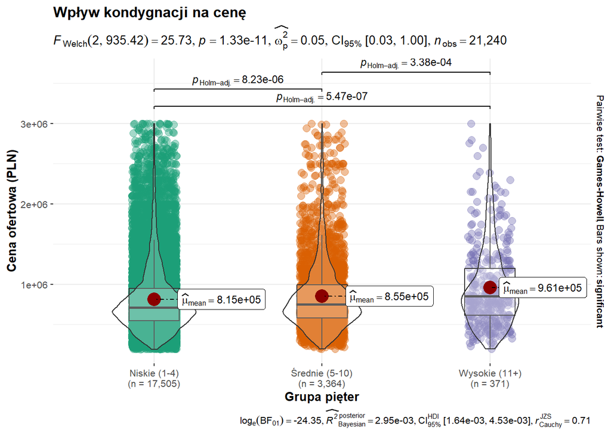

**Do sekcji 2 Piętro:** Analiza wykazała istotne statystycznie różnice w cenach w zależności od kondygnacji ($p < 0.001$). Obserwujemy wyraźny trend rosnący:

Premia za widok: Najdroższe są mieszkania na wysokich piętrach (11+) (śr. ~961 tys. PLN).Standard: Mieszkania na piętrach niskich (1-4) i średnich (5-10) osiągają niższe wyceny (odpowiednio ~815 tys. i ~855 tys. PLN).Wniosek: Rynek premiuje mieszkania położone wysoko (panoramiczne), traktując je jako towar bardziej luksusowy, podczas gdy niższe kondygnacje w wysokiej zabudowie są wyceniane niżej.

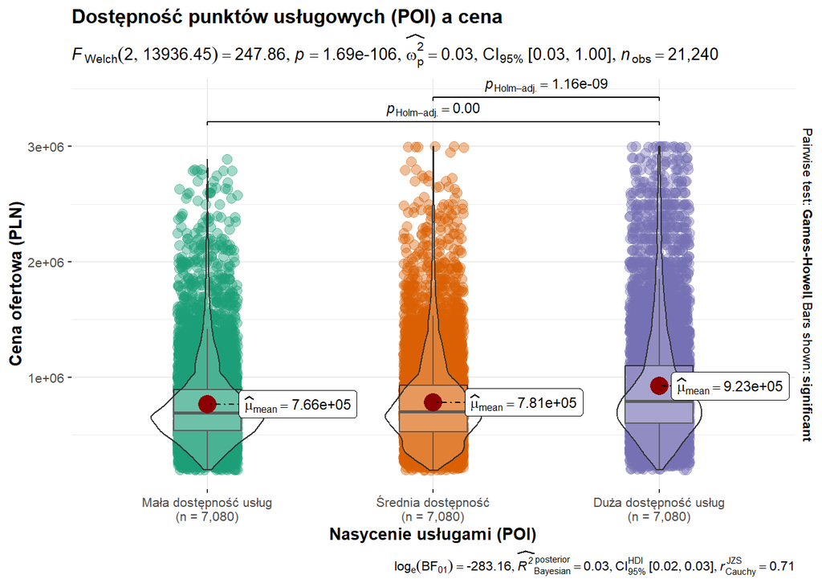

**Do sekcji 3 Dostępność usług / POI:** Istnieje silna zależność między nasyceniem okolicy usługami (POI) a ceną ofertową nieruchomości ($p < 0.001$).Efekt lokalizacji:

Mieszkania w strefach o dużej dostępności usług są średnio o ponad 140 tys. PLN droższe (śr. ~923 tys. PLN) niż te w strefach o średniej dostępności (~781 tys. PLN).Wniosek: Bliskość szkół, restauracji i sklepów jest silnie skorelowana z wyższą ceną, co potwierdza, że lokalizacja “wszystko pod ręką” jest wysoce pożądana przez kupujących.

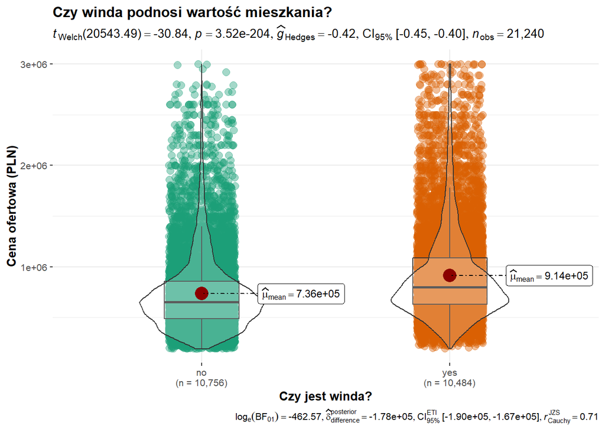

**Do sekcji 4 Winda:** Test t-Studenta (z poprawką Welcha) wskazuje na gigantyczną różnicę w cenach ($p < 0.001$).

Wartość udogodnienia:

Mieszkania w budynkach z windą są średnio o blisko 180 tys. PLN droższe (śr. ~914 tys. PLN) niż te bez windy (~736 tys. PLN).Kontekst: Należy pamiętać, że winda często koreluje z nowszym budownictwem (apartamentowce) lub wyższym standardem, podczas gdy brak windy jest typowy dla starszych bloków z wielkiej płyty (do 4 pięter) i kamienic, co dodatkowo pogłębia różnicę cenową.

# 4.Podsumowanie

## 4.1. Charakterystyka Cenowa i Struktura Rynku

Bloki: Najbardziej przewidywalny i przystępny cenowo segment (śr. ~713 tys. PLN), stanowiący fundament rynku masowego.

Analiza techniczna wykazała gigantyczną premię za udogodnienia: obecność windy podnosi średnią wartość mieszkania o blisko 180 000 PLN, a lokale na wysokich piętrach (11+) są wyceniane istotnie wyżej niż te na niższych kondygnacjach, co potwierdza zjawisko „premii za widok”.

## 4.3. Geografia Cen i Modele Rozwoju Miast

Polska pozostaje rynkiem głęboko spolaryzowanym. Warszawa (śr. >18 000 PLN/m²) deklasuje pozostałe ośrodki, tworząc wraz z Trójmiastem i Krakowem grupę „rynków tier-1”. Miasta takie jak Radom czy Częstochowa, z cenami poniżej 7 500 PLN/m², stanowią odrębny biegun ekonomiczny.

Szczegółowa analiza porównawcza Warszawy i Gdańska ujawniła dwa odmienne modele urbanistyczne:

Warszawa (Model Monocentryczny):Występuje tu klasyczna renta lokalizacyjna – cena spada liniowo wraz z oddalaniem się od Pałacu Kultury. Nowe inwestycje są wypychane na peryferia („efekt obwarzanka”), tworząc jasny pierścień nowej zabudowy wokół ciemniejszego, historycznego rdzenia.

Gdańsk (Model Policentryczny/Pasmowy): Ceny nie spadają liniowo.Nowa zabudowa nie otacza miasta, lecz ekspanduje na południe oraz wypełnia luki w pasie nadmorskim.

## 4.5. Końcowe Wnioski Statystyczne

Przeprowadzone testy parametryczne (Welch ANOVA, Games-Howell) na próbie ponad 20 tys. ofert pozwoliły na sformułowanie wniosków o wysokim poziomie istotności statystycznej ($p < 0.001$):

Typ budynku jest kluczowym dyskryminatorem ceny (apartamentowiec > kamienica > blok).

Lokalizacja wertykalna ma znaczenie: najwyższe piętra są towarem luksusowym, partery i niskie piętra są wyceniane niżej.

Infrastruktura bezpośrednio przekłada się na wartość: strefy o wysokim nasyceniu POI są średnio o 140 000 PLN droższe od stref o nasyceniu średnim.